# Notebook

### DAR Estimation non paramétrique et Apprentissage Statistique

### Exercice 1: Estimation de densité par la méthode du noyau

#### Contexte

L’estimation de densité par la méthode du noyau (ou estimation à noyau, kernel density estimation - KDE) est une technique non paramétrique utilisée pour estimer la fonction de densité de probabilité d’une variable aléatoire à partir d’un échantillon de données. Elle est particulièrement utile quand on ne connaît pas la forme de la distribution sous-jacente des données.

#### Objectif

L’objectif principal de l’estimation de densité par noyau (KDE) est de reconstruire une approximation lisse de la fonction de densité de probabilité d'une variable aléatoire à partir d'un échantillon de données, sans faire d’hypothèse sur la forme de la distribution sous-jacente.

```python
# Bibliothèques recommandées
import numpy as np
import matplotlib.pyplot as plt
from scipy.stats import gaussian_kde
```

### Partie 1 : Construction d’un estimateur a noyau

##### 1. Ecrivons une fonction KG qui prend en paramètre u ∈ R et renvoie KG(u) o` u KG est le noyau gaussien centre réduit

La fonction 𝐾G représentant le noyau gaussien centré réduit est utilisé dans l’estimation de densité à noyau (Kernel Density Estimation, KDE) et permet de répartir la masse de probabilité autour de chaque observation 𝑥𝑖, avec une forme en cloche (la célèbre courbe de Gauss).

```python
def KG(u):
    return((1/np.sqrt(2*np.pi)) * np.exp(-0.5 * u**2))
```

##### 2. Ecrivons une fonction KE qui prend en paramètre u ∈ R et renvoie KE(u) où KE est le noyau d’Epanechnikov

La fonction 𝐾𝐸 représentant le noyau d’Epanechnikov, est une des fonctions noyaux utilisées pour l’estimation de densité par noyau (KDE). Contrairement au noyau gaussien qui infiniment étendu, le noyau d’Epanechnikov est compact, ce qui le rend plus efficace en théorie.

###### K(u) = { (3/4)(1 - u²) si |u| ≤ 1 ; 0 sinon }

```python
def KE(u):
    if np.abs(u) <= 1:
        return 0.75 * (1 - u**2)
    else :
        return 0
```

##### 3. Ecrivons une fonction fchap G qui prend en paramètres un vecteur X, x ∈ R, h > 0, et renvoie la valeur de l’estimation de Parzen-Rosenblatt au point x avec le noyau gaussien et la fenêtre h.

La fonction fchap G est une fonction qui implémente l'estimation de densité de Parzen-Rosenblatt, en utilisant un noyau gaussien et un paramètre de lissage (largeur de bande) donné. Pour chaque point x de l'échantillon X, la fonction calcule une somme pondérée des valeurs du noyau gaussien pour tous les points de l'échantillon X, en utilisant la distance normalisée par la largeur de bande h

###### f_hat(x) = (1 / (n * h)) * sum(K((x - xi) / h) for xi in X)

```python
def fchap_G(X, x, h):
    n = len(X)
    return (1 / (n * h)) * np.sum(KG((X - x) / h))
```

##### 4. Fonction fchap_E (estimation de Parzen-Rosenblatt avec noyau d’Epanechnikov)

La fchap_E doit prendre en entrée un vecteur de données X, un point x où l'on souhaite estimer la densité, et un paramètre de lissage h, et renvoie la valeur de l'estimation de densité de Parzen-Rosenblatt au point x en utilisant le noyau d'Epanechnikov.

```python
def fchap_E(X, x, h):
    n = len(X)
    return (1 / (n * h)) * sum(KE((x - X_i) / h) for X_i in X)
```

##### 5. Simulons un échantillon X0 de taille n = 50 selon la loi gaussienne centrée réduite.

```python
np.random.seed(0)
X0 = np.random.normal(0, 1, 50)
```

##### 6. Complétons le code ci-dessous pour tracer la densité f0 de la loi N(0,1), ainsi que les données de l’´echantillon X0 :

###### nbpts = 1000

###### x = seq(-4,4,length.out=nbpts)

###### f0 = ...

###### plot(x,f0,type="l",lwd=2)

###### points(X0,rep(0,50),col="green",lwd=2)

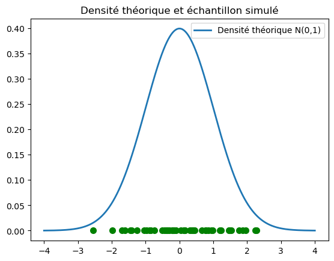

```python
nbpts = 1000
x = np.linspace(-4, 4, nbpts)
f0 = (1/np.sqrt(2*np.pi)) * np.exp(-0.5 * x**2)

plt.plot(x, f0, label='Densité théorique N(0,1)', linewidth=2)
plt.scatter(X0, [0]*len(X0), color='green', linewidth=2)
plt.title('Densité théorique et échantillon simulé')
plt.legend()
plt.show()
```

##### Interprétation

Il s'agit de la représentation de la distribution de la loi gaussienne centrée réduite

##### 7. Estimons la densité de X0 avec les estimateurs fchap_G et chap_E pour h = 0.2, 0.05 et 0.8

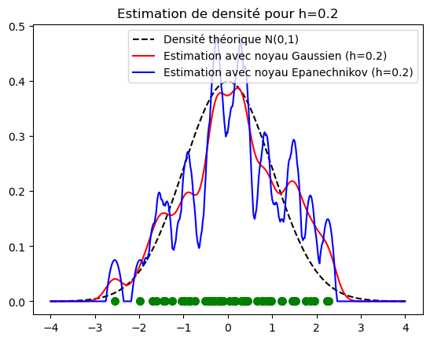

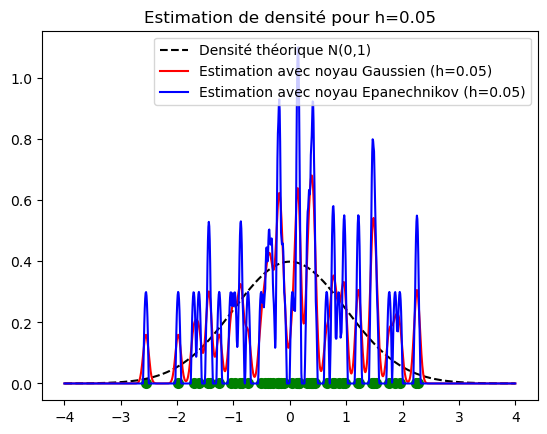

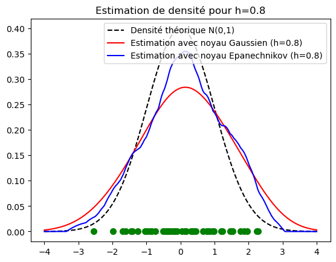

```python
hs = [0.2, 0.05, 0.8]
for h in hs:
    hatf_G = [fchap_G(X0, xi, h) for xi in x]
    hatf_E = [fchap_E(X0, xi, h) for xi in x]

    plt.plot(x, f0, 'k--', label='Densité théorique N(0,1)')
    plt.plot(x, hatf_G, 'r-', label=f'Estimation avec noyau Gaussien (h={h})')
    plt.plot(x, hatf_E, 'b-', label=f'Estimation avec noyau Epanechnikov (h={h})')
    plt.scatter(X0, [0]*len(X0), color='green', linewidth=2)
    plt.title(f'Estimation de densité pour h={h}')
    plt.legend()
    plt.show()
```

##### 8. Simuler un échantillon X0 de taille n = 50 selon la loi gaussienne centrée réduite

###### hatf = density(X0, bw=0.1, kernel="gaussian", n=nbpts, from=-4, to=4)$y

L'equivalent de la fonction density en python est gaussian_kde Simulation d’un échantillon X0

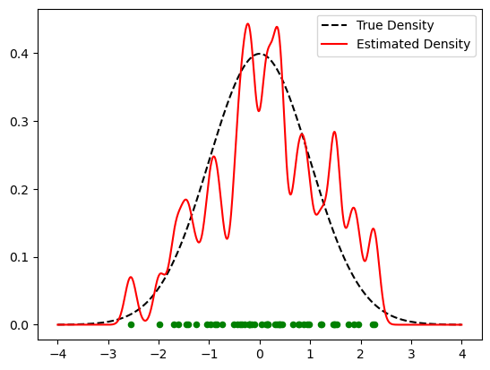

```python
np.random.seed(0)
X0 = np.random.normal(0, 1, 50)

# Utilisation de la fonction gaussian_kde pour estimer la densité
nbpts = 1000
x = np.linspace(-4, 4, nbpts)
kde = gaussian_kde(X0, bw_method=0.1)
hatf = kde(x)

# Tracé de la densité estimée
f0 = (1/np.sqrt(2*np.pi)) * np.exp(-0.5 * x**2)

plt.plot(x, f0, 'k--', label='True Density')
plt.plot(x, hatf, 'r-', label='Estimated Density')
plt.scatter(X0, np.zeros_like(X0), color="green", s=20)
plt.legend()
plt.show()
```

##### Interprétation

La fonction gaussian_kde() (density pour R) a une distribution plus étendue que celle de la loi normale centrée réduite

### Partie 2

```python
np.random.seed(0)
h_values = np.linspace(0.1, 1.6, 40)  # Par exemple, 10 valeurs de h entre 0.1 et 1.0
J_values = np.random.rand(10)  # Exemple de valeurs aléatoires pour J_values

# Détermination de la bande passante optimale
h_opt = h_values[np.argmin(J_values)]

# Tracé de la densité correspondante
nbpts = 1000
x = np.linspace(-4, 4, nbpts)
f0 = (1/np.sqrt(2*np.pi)) * np.exp(-0.5 * x**2)
hatf_opt = [fchap_G(X0, y, h_opt) for y in x]
```

##### 10. Determinons hopt et tracons la densité correspondante

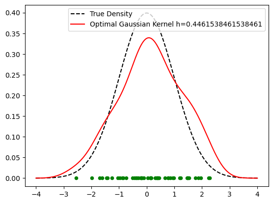

```python
plt.plot(x, f0, 'k--', label='True Density')
plt.plot(x, hatf_opt, 'r-', label=f'Optimal Gaussian Kernel h={h_opt}')
plt.scatter(X0, np.zeros_like(X0), color="green", s=20)  # Utilisation de 's' au lieu de 'lwd'
plt.legend()
plt.show()
```

##### Interprétation

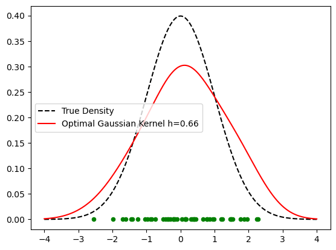

```python
h_values = np.linspace(0.1, 1.6, 40)  # Par exemple, 10 valeurs de h entre 0.1 et 1.0
J_values = np.random.rand(10)  # Exemple de valeurs aléatoires pour J_values

# Détermination de la bande passante optimale
h_opt = 0.66

# Tracé de la densité correspondante
nbpts = 1000
x = np.linspace(-4, 4, nbpts)
f0 = (1/np.sqrt(2*np.pi)) * np.exp(-0.5 * x**2)
hatf_opt = [fchap_G(X0, y, h_opt) for y in x]

plt.plot(x, f0, 'k--', label='True Density')
plt.plot(x, hatf_opt, 'r-', label=f'Optimal Gaussian Kernel h={h_opt}')
plt.scatter(X0, np.zeros_like(X0), color="green", s=20)  # Utilisation de 's' au lieu de 'lwd'
plt.legend()
plt.show()
```

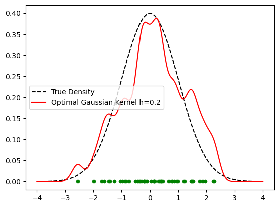

```python
h_values = np.linspace(0.1, 1.6, 40)  # Par exemple, 10 valeurs de h entre 0.1 et 1.0
J_values = np.random.rand(10)  # Exemple de valeurs aléatoires pour J_values

# Détermination de la bande passante optimale
h_opt = 0.2

# Tracé de la densité correspondante
nbpts = 1000
x = np.linspace(-4, 4, nbpts)
f0 = (1/np.sqrt(2*np.pi)) * np.exp(-0.5 * x**2)
hatf_opt = [fchap_G(X0, y, h_opt) for y in x]

plt.plot(x, f0, 'k--', label='True Density')
plt.plot(x, hatf_opt, 'r-', label=f'Optimal Gaussian Kernel h={h_opt}')
plt.scatter(X0, np.zeros_like(X0), color="green", s=20)  # Utilisation de 's' au lieu de 'lwd'
plt.legend()
plt.show()
```

##### 11. Tracons les deux densités correspondantes sur un même graphique.

[figure not shown]

```python
from scipy.stats import gaussian_kde
x_vals = np.linspace(-4, 4, nbpts)
kde_auto = gaussian_kde(X0, bw_method='silverman')
auto_density = kde_auto(x_vals)

# Estimation avec h_opt
hatf_opt = np.array([fchap_G(X0, x, h_opt) for x in x_vals])

plt.figure(figsize=(10, 5))
plt.plot(x_vals, f0, '--', label="Densité théorique", linewidth=2)
plt.plot(x_vals, hatf_opt, label=f"Densité (LOO, h={round(h_opt,3)})", linewidth=2)
plt.plot(x_vals, auto_density, label="bw.ucv", linewidth=2, linestyle="dotted")
plt.legend()
plt.title("Comparaison : hopt vs bw.ucv")
plt.grid()
plt.show()
```

### Exercice 2 : Modélisation du loyer - étude de cas sur un marché immobilier

#### Contexte de l'étude

L’étude du marché immobilier d’une ville est souvent un exercice complexe nécessitant une compréhension approfondie des différents facteurs qui influent sur les prix des loyers. Parmi ces facteurs, la taille de l’habitation, le nombre de pièces disponibles et d’autres caractéristiques jouent un rôle crucial dans la détermination des prix.

#### Objectif de l'étude

L'objectif de cette étude est de construire un modèle de régression linéaire multiple pour prédire le montant du loyer en fonction des deux autres variables.

```python
# Bibliothèque utilisées
import pandas as pd
import matplotlib.pyplot as plt
import seaborn as sns
from sklearn.linear_model import LinearRegression
from sklearn.model_selection import train_test_split
import numpy as np
from sklearn.metrics import mean_squared_error
```

#### 1. Importation et Exploration des données

##### Importation des données

La base de données au format CSV rencontre une erreur donc nous convertie le fichier au format excel.

```python
file_path = 'C:/Users/LENOVO/OneDrive - ACTED/Documents/CYPRIEN_28_03_2025/Master/Apprentissage Statistique/DAR/dataset.xlsx'
dataset = pd.read_excel(file_path)
```

##### Affichons les types de variables

```python
print(dataset.dtypes)
```

[output not shown]

##### Affichons les premières lignes des données

```python
print(dataset.head())
```

```
   Surface  Loyer  Rooms
0     33.0   55.0      1
1     14.0   11.7      1
2     22.0   22.0      2
3     11.6   17.5      2
4     17.0   18.0      1
```

##### Affichons les statistiques descriptives des variables

```python
print(dataset.describe())
```

```
          Surface       Loyer       Rooms
count  200.000000  200.000000  200.000000
mean    41.278950   39.977810    2.440000
std     18.836139   19.435838    1.132614
min      8.000000    8.000000    1.000000
25%     25.000000   24.375000    1.000000
50%     43.850000   40.000000    2.000000
75%     56.000000   55.000000    3.000000
max     78.000000   78.900000    4.000000
```

#### Interprétation :

##### Affichons les visuels des données

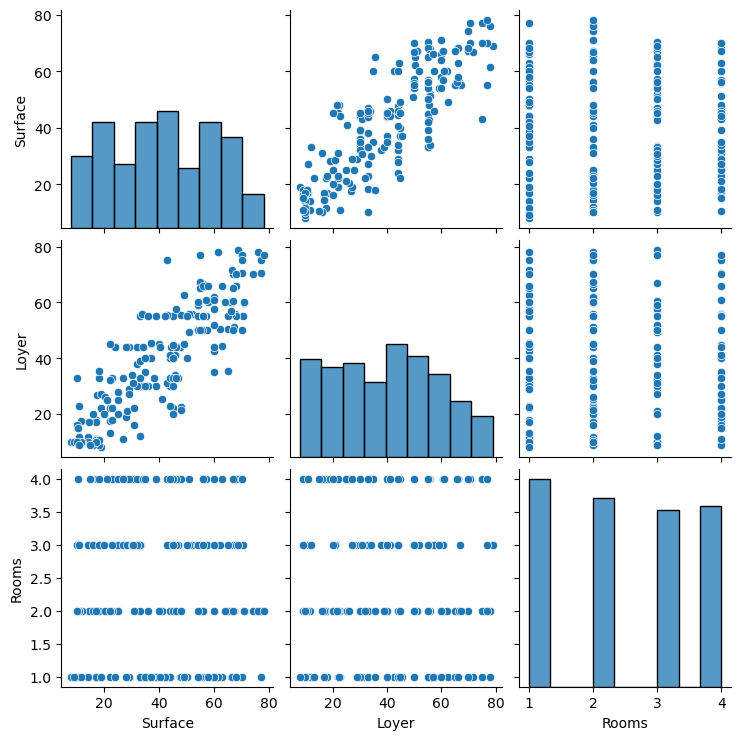

```python
sns.pairplot(dataset) # module de la bibliothèque Seaborn (basée sur matplotlib) qui permet de faire la visualisation statistique
plt.show() # permet de forcer l'affichage graphique
```

#### Interprétation :

##### Affichons la matrice de corrélation

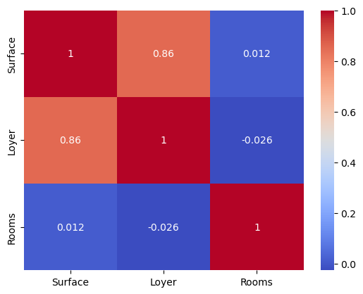

```python
sns.heatmap(dataset.corr(), annot=True, cmap='coolwarm')
plt.show()
```

#### Interprétation :

La matrice de corrélation de corrélation montre qu'il existe une forte corrélation linéaire positive entre la surface et le loyer.  
Il existe une très faible corrélation linéaire négative entre le loyer et le nombre de pièce. De même il existe une très faible corrélation linéaire positive entre la surface et le nombre de pièce.

#### 2. Modélisation

##### Selection du target et features

```python
features = ['Surface', 'Rooms']
X = dataset[features]
y = dataset.Loyer
```

##### Divisons les données en ensembles d'apprentissage et de test et créons le modèle de régression linéaire

```python
X_train, X_test, y_train, y_test = train_test_split(X, y, test_size=0.2, random_state=42)

model = LinearRegression()
```

##### Entraînons le modèle et affichons les coefficients du modèle

```python
model.fit(X_train, y_train)

print(f'Coefficients: {model.coef_}')
print(f'Intercept: {model.intercept_}')
```

```
Coefficients: [ 0.86883991 -0.8884175 ]
Intercept: 6.579256860987357
```

##### Interprétation :

Les coéfficients de régression associés aux variables Surface et Rooms sont respectivement 0.8688 et -0.8884. Cela signifie que que si la surface augmente d'un mètre carré, le loyer augmente de 868,8 FCFA.\ De même si le nombre de pièce augmente d'une unité, le prix du loyer baisse de 888,4 FCFA. Cela est insignifiant et non logique et pourrait s'expliquer une absence de rélation linéaire entre ces deux variables.  
La constante vaut 6.57925, cela signifie que le prix moyen d'unloyer est est de 6579.25

#### 3. Prédiction :

```python
surface = 70
pieces = 4
predicted_rent = model.predict(X)
print(f'Prédiction du loyer pour une habitation de {surface} m² avec {pieces} pièces: {predicted_rent[0]}')
```

[output not shown]

#### 4. Diagnostic du modèle

##### 4.1 - Analysons les résidus du modèle (distribution, tendance).

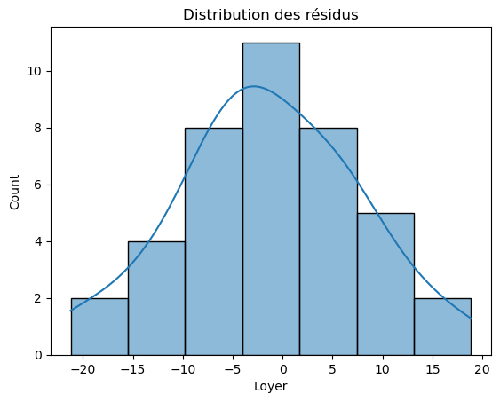

```python
# Déterminons et Analysons les résidus
y_pred = model.predict(X_test)
residuals = y_test - y_pred
sns.histplot(residuals, kde=True)
plt.title('Distribution des résidus')
plt.show()
```

#### Interprétation :

Le graphique montre que les résidus semblent suivre une distribution normale centrée.

##### 4.2 - Vérifions les hypothèses de linéarité, d'homoscédasticité et de normalité des résidus

##### Test de linéarité : Méthodes visuelles avec scikit-learn

###### S'il y a une répartition aléatoire des résidus autour de 0 → le modèèle est linéaire

###### Si la courbe est en forme de U ou en vague → il y a non-linéarité

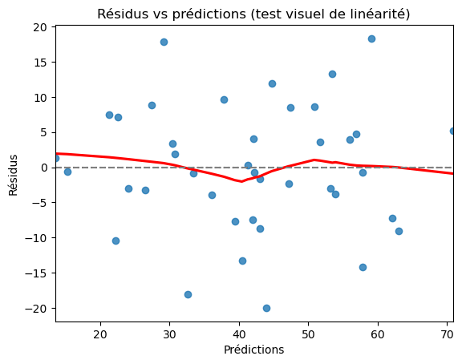

```python
sns.residplot(x=y_pred, y=residuals, lowess=True, line_kws={'color': 'red'})
plt.axhline(0, color='gray', linestyle='--')
plt.xlabel("Prédictions")
plt.ylabel("Résidus")
plt.title("Résidus vs prédictions (test visuel de linéarité)")
plt.show()
```

#### Interprétation :

Les points bleus représentent chaque observation (résidu vs prédiction)  
La courbe rouge représente la courbe de tendance des residus.  
Les résidus sont globalement centrés autour de 0. La courbe ne semble pas avoir une tendance en U. En conclusion nous pouvons dire que le modèle semble assez linéaire.

#### Test d'homoscédasticité : méthodes visuelles

#### Homoscédasticité (variance des résidus stable) :

Les points sont répartis de façon aléatoire autour de la ligne 0 (ligne horizontale).  
La dispersion verticale des points reste à peu près constante sur tout l’axe des prédictions.  
Pas de forme particulière (pas de cône, pas de courbe, pas d'entonnoir).

#### Hétéroscédasticité (variance non stable) :

La dispersion des résidus augmente ou diminue avec les prédictions.  
On observe souvent une forme en cône ou en entonnoir : Petit au début, plus grand à la fin implique que la variance des résidus augmente avec les prédictions.

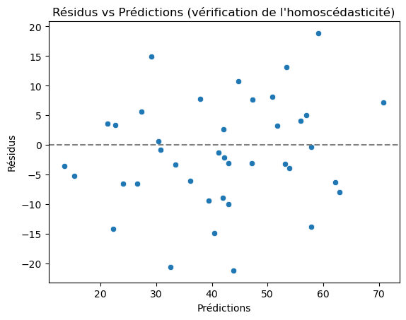

```python
sns.scatterplot(x=y_pred, y=residuals)
plt.axhline(0, color='gray', linestyle='--')
plt.xlabel("Prédictions")
plt.ylabel("Résidus")
plt.title("Résidus vs Prédictions (vérification de l'homoscédasticité)")
plt.show()
```

#### Interprétation :

Les points sont dispersés de manière assez uniforme autour de la ligne horizontale à 0.  
Il n'y a pas de forme particulière (pas de cône, ni entonnoir, ni V).  
La dispersion verticale des résidus semble relativement constante quel que soit le niveau de prédiction (de 10 à 70).  
On peut donc dire qu'il y a homoscédasticité et donc l’erreur du modèle est stable.

#### Test de normalité des résidus : Test de Shapiro

##### H0 : Les résidus suivent une loi normale

##### H1 : Les résidus ne suivent pas une loi normale

On rejette H0 si la p_value <= 0.05

```python
from scipy.stats import shapiro

stat, p_value = shapiro(residuals)
print(f'Statistique de test = {stat:.4f}, p-value = {p_value:.4f}')
```

```
Statistique de test = 0.9896, p-value = 0.9695
```

#### Interprétation :

La p-value =0.9695 est supérieure à 0.05, on ne rejette pas H0, donc les résidus suivent une distribution normale.

#### 5. Évaluation et validation

##### Évaluons les performances du modèle sur les données de test : calcul du RMSE

###### RMSE = Racine carrée de l'erreur quadratique moyenne. Il mesure l’écart moyen entre les valeurs prédites et les valeurs observées (vraies). Il s’exprime dans la même unité que la variable cible et permet de se prononcer sur la stabilité du modèle.

```python
rmse = np.sqrt(mean_squared_error(y_test, y_pred))
print(f'RMSE: {rmse}')
```

```
RMSE: 9.092688753283774
```

#### Interprétation :

RMSE = 9.09268, cela signifie que les prédictions s’écartent de 9092,68 FCFA par rapport aux vraies valeurs. Le modèle semble être instable.

#### 6. Discussion

#### Identifions la variable ayant le plus d'impact sur le loyer : Analysons les coefficients du modèle

La matrice de corrélation a montré qu'il existe une forte rélation entre le loyer et la surface de l'habitation. Les coefficients de régressions montre que si la surface de l'habitation augmente d'un mètre carré, le prix du loyer augmente de 868,8 FCFA. Ainsi la surface de l'habitation est la variable ayant le plus d'impact sur le loyer.

##### Proposons des améliorations possibles

Pour augmenter la modélisation du prix du loyer des logements, nous suggérons d'augmenter le nombre de variable explicative et aussi du nombre d'observation. En effet, le nombre de pièce est une variable quantitative mais à l'apparence d'une variable catégorielle.

### Exercice 3 : Machine Learning et naufrage du Titanic - Survivre au Titanic

#### Contexte :

Le naufrage du Titanic est l’un des accidents maritimes les plus célèbres de l’histoire. En 1912, ce paquebot réputé insubmersible coule lors de son voyage inaugural. Grâce aux données recueillies sur les passagers, il est possible d’explorer les facteurs ayant influencé les chances de survie.

#### Objectif :

L'objectif de cette étude est de donstruire un modèle de classification supervisé permettant de prédire si un passager a survécu ou non, à partir des variables explicatives fournies.

#### Bibliothèques utilisées

```python
import pandas as pd
import numpy as np
from sklearn.preprocessing import LabelEncoder
import matplotlib.pyplot as plt
import seaborn as sns
from sklearn.model_selection import train_test_split
from sklearn.ensemble import RandomForestClassifier
from sklearn.metrics import confusion_matrix, accuracy_score, precision_score, recall_score
from sklearn.linear_model import LogisticRegression
from sklearn.tree import DecisionTreeClassifier
from sklearn.metrics import accuracy_score
from sklearn.impute import SimpleImputer
```

#### 1. Préparation des donnees

##### Importation des données

```python
file_path = 'C:/Users/LENOVO/OneDrive - ACTED/Documents/CYPRIEN_28_03_2025/Master/Apprentissage Statistique/DAR/titanic/titanic/train.csv'
titanic = pd.read_csv(file_path)
```

```python
# Vérifions l’existence de valeurs manquantes et les traiter.
titanic.isnull().sum()
```

```
PassengerId      0
Survived         0
Pclass           0
Name             0
Sex              0
Age            177
SibSp            0
Parch            0
Ticket           0
Fare             0
Cabin          687
Embarked         2
dtype: int64
```

##### Interprétation

La variable "Age" contient 177 valeurs manquantes. La variable "Cabin" 687 valeurs manquantes et la variable "Embarked" 2 valeurs manquantes. A la suite des analyses nous allons remplacés les valeurs manquantes de la variables "Age" par l'âge moyen des passagers

##### Convertissons les variables qualitatives au bon format (facteurs).

##### Affichons les types des variables

```python
print(titanic.dtypes)
```

```
PassengerId      int64
Survived         int64
Pclass           int64
Name            object
Sex             object
Age            float64
SibSp            int64
Parch            int64
Ticket          object
Fare           float64
Cabin           object
Embarked        object
dtype: object
```

##### Conversions des variables Pclass, Sex et Embarked

```python
titanic['Pclass'] = titanic['Pclass'].astype('category')
titanic['Embarked'] = titanic['Embarked'].map({'C':1,'Q':2,'S':3})
titanic['Sex'] = titanic['Sex'].map({'male':1,'female':0}) # grâce à pandas
```

##### Vérification des variables converties

```python
print(titanic.dtypes)
```

```
PassengerId       int64
Survived          int64
Pclass         category
Name             object
Sex             float64
Age             float64
SibSp             int64
Parch             int64
Ticket           object
Fare            float64
Cabin            object
Embarked        float64
dtype: object
```

##### Analyse des distributions et résumé statistique les variables clés

##### Résumé statistiques

```python
print(titanic.describe())
```

```
       PassengerId    Survived  Sex         Age       SibSp       Parch  \
count   891.000000  891.000000  0.0  714.000000  891.000000  891.000000
mean    446.000000    0.383838  NaN   29.699118    0.523008    0.381594
std     257.353842    0.486592  NaN   14.526497    1.102743    0.806057
min       1.000000    0.000000  NaN    0.420000    0.000000    0.000000
25%     223.500000    0.000000  NaN   20.125000    0.000000    0.000000
50%     446.000000    0.000000  NaN   28.000000    0.000000    0.000000
75%     668.500000    1.000000  NaN   38.000000    1.000000    0.000000
max     891.000000    1.000000  NaN   80.000000    8.000000    6.000000

             Fare
count  891.000000
mean    32.204208
std     49.693429
min      0.000000
25%      7.910400
50%     14.454200
75%     31.000000
max    512.329200
```

##### Analyse des distributions : package matplotlib et Seaborn

###### Distribution de l'âge

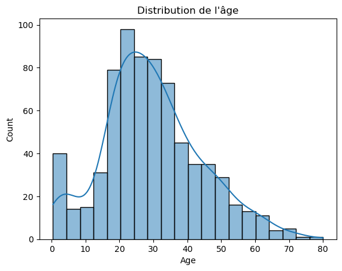

```python
sns.histplot(titanic['Age'], kde=True)
plt.title('Distribution de l\'âge')
```

###### Distribution des tarifs

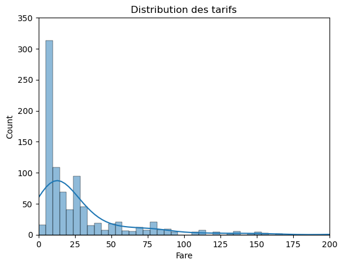

```python
sns.histplot(titanic['Fare'], kde=True)
plt.xlim(0,200)
plt.ylim(0,350)
plt.title('Distribution des tarifs')
```

##### Interprétation

Le graphique présenté montre la distribution des tarifs payés par les passagers du Titanic. Il s'agit d'un histogramme avec une courbe de densité superposée. L'histogramme de l'âge semble suivre une distribution normale. Les tarifs n'ont pas une distribution normale

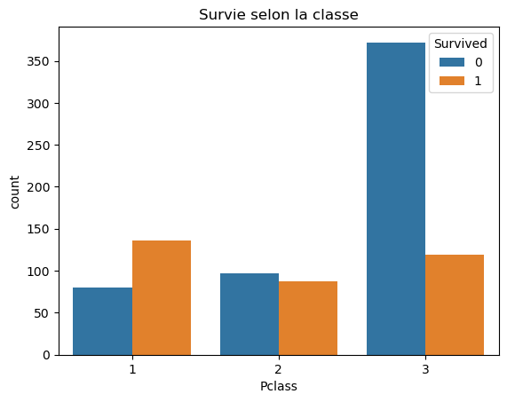

```python
# 2. Exploration visuelle
# a. Visualiser la distribution des survivants selon la classe, le sexe et l'âge
# Distribution des survivants selon la classe

sns.countplot(data=titanic, x='Pclass', hue='Survived')
plt.title("Survie selon la classe")
plt.show()
```

### Les passagers de 1ʳᵉ classe ont été favorisés tandis que les passagers de 3ᵉ classe ont été les plus touchés par le naufrage.

[figure not shown]

```python
# Distribution des survivants selon le sexe
sns.countplot(data=titanic, x='Sex', hue='Survived')
plt.title("Survie selon le sexe")
plt.show()
```

##### Interprétation

Les femmes ont été largement favorisées, probablement à cause de la règle « les femmes et les enfants d’abord » appliquée lors de l’évacuation du Titanic.

##### Distribution des survivants selon l'âge

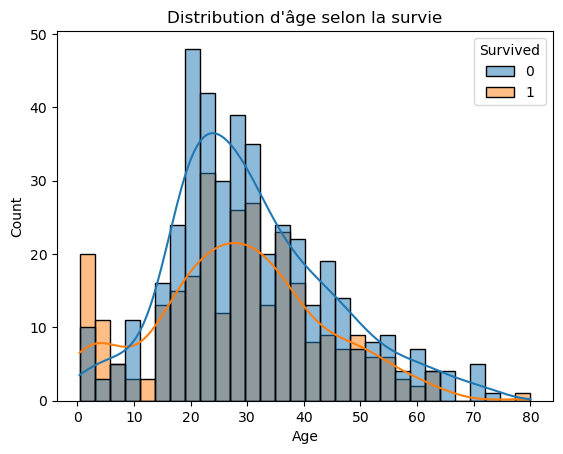

```python
sns.histplot(data=titanic, x='Age', hue='Survived', bins=30, kde=True)
plt.title("Distribution d'âge selon la survie")
plt.show()
```

##### Interprétation

Le graphique présente la distribution des âges des passagers du Titanic selon leur statut de survie, en distinguant les individus décédés (Survived = 0, en bleu) des survivants (Survived = 1, en orange). Les données sont visualisées à l’aide d’histogrammes superposés accompagnés de courbes de densité pour chaque groupe.

##### Selection des variables

```python
features = ['Pclass','Sex','Age','SibSp','Parch','Fare','Embarked']
X = titanic[features]
y = titanic['Survived']
```

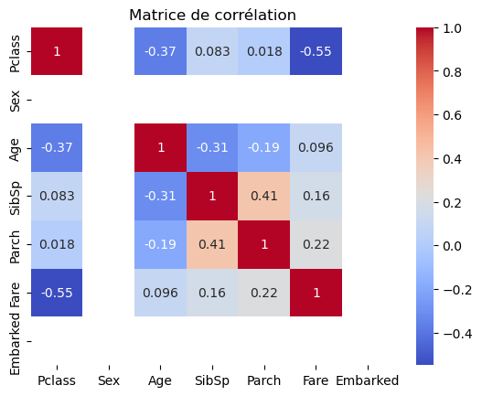

```python
corr_matrix = X.corr()
sns.heatmap(corr_matrix, annot=True, cmap='coolwarm')
plt.title('Matrice de corrélation')
```

##### Interprétation:

Le graphique présente une matrice de corrélation de Pearson entre différentes variables quantitatives et transformées du jeu de données Titanic. La matrice évalue l’intensité et le sens de la relation linéaire entre chaque paire de variables. Les coefficients de corrélation varient entre -1 (corrélation parfaitement négative) et +1 (corrélation parfaitement positive). Une échelle de couleur allant du bleu (corrélation négative) au rouge (corrélation positive) facilite la lecture visuelle.

#### 3. Construction d’un modèle prédictif

##### a. Séparons les données en un ensemble d'apprentissage et un ensemble de test

```python
X_train, X_test, y_train, y_test = train_test_split(X, y, test_size=0.2, random_state=1)
```

##### b. Construire un modèle de classification (ex. : forêt aléatoire) \

##### construire le modèle

```python
model = RandomForestClassifier(n_estimators=100, random_state=1)
model.fit(X_train, y_train)
```

```
RandomForestClassifier(random_state=1)
```

##### c. Évaluer les performances du modèle\

##### Prédictions

```python
y_pred = model.predict(X_test)

# Évaluation
print('Accuracy:', accuracy_score(y_test, y_pred))
print('Precision:', precision_score(y_test, y_pred))
print('Recall:', recall_score(y_test, y_pred))
print('Confusion Matrix:\n', confusion_matrix(y_test, y_pred))
```

```
Accuracy: 0.6368715083798883
Precision: 0.5645161290322581
Recall: 0.4794520547945205
Confusion Matrix:
 [[79 27]
 [38 35]]
```

#### 4. Interprétation des résultats

##### a. Identifions les variables les plus importantes dans la prédiction

```python
importances = model.feature_importances_
feature_names = X.columns
feature_importances = pd.DataFrame({'Feature': feature_names, 'Importance': importances})
feature_importances = feature_importances.sort_values(by='Importance', ascending=False)
print(feature_importances)
```

```
    Feature  Importance
1       Sex    0.261534
2       Age    0.259528
5      Fare    0.256661
0    Pclass    0.094179
3     SibSp    0.048537
4     Parch    0.042416
6  Embarked    0.037145
```

##### Interprétaton

Le tableau présente les poids relatifs (importances) attribués aux variables explicatives dans le cadre d’un modèle supervisé visant à prédire la survie des passagers du Titanic. Ces importances traduisent l’impact moyen de chaque variable sur les décisions du modèle, en fonction de la réduction d’impureté

##### b. Interprétons les résultats et proposer des améliorations possibles du modèle

Pour améliorer le modèle, on pourrait essayer d'autres algorithmes de classification, ajuster les hyperparamètres, ou ajouter des interactions entre les variables.

#### 5. Extension possible (optionnel) : Comparons les modèles régression logistique, arbre de decision

##### Imputation des valeurs manquantes

```python
imputer = SimpleImputer(strategy='mean')
X_train_imputed = imputer.fit_transform(X_train)
X_test_imputed = imputer.transform(X_test)
```

##### Régression logistique

```python
log_model = LogisticRegression(random_state=1)
log_model.fit(X_train_imputed, y_train)
log_pred = log_model.predict(X_test_imputed)
```

##### Arbre de décision

```python
tree_model = DecisionTreeClassifier(random_state=1)
tree_model.fit(X_train_imputed, y_train)
tree_pred = tree_model.predict(X_test_imputed)
```

##### Évaluation des modèles : affichages des résultats

```python
print('Logistic Regression Accuracy:', accuracy_score(y_test, log_pred))
print('Decision Tree Accuracy:', accuracy_score(y_test, tree_pred))
```

```
Logistic Regression Accuracy: 0.664804469273743
Decision Tree Accuracy: 0.6536312849162011
```

##### b. Testons une validation croisée

```python
# Importons le module cross_val_score de la bibliothèque scikit-learn
from sklearn.model_selection import cross_val_score
```

##### Validation croisée pour la forêt aléatoire

```python
cv_scores = cross_val_score(model, X, y, cv=5)
print('Cross-validated scores:', cv_scores)
print('Mean cross-validated score:', cv_scores.mean())
```

```
Cross-validated scores: [0.66480447 0.62921348 0.69662921 0.69662921 0.70224719]
Mean cross-validated score: 0.6779047140794676
```